# データサイエンティスト テスト問題

上西 フラビオ

## 概要 (Briefing)

サービスAを対象に、アプリのログインを促すために6/3~6/9の1週間、一部のユーザーに対してメッセージをプッシュする施策を行いました。

メッセージタイプには“A”と“B”の2種類があり、それぞれ受け取るユーザー群が異なります。メッセージのプッシュ回数については1回のユーザー群と2回のユーザー群があります。 メッセージプッシュの効果として翌週(6/10 ~ 6/16)のログイン回数が増えたことが認められれば、メッセージのプッシュを全ユーザーに展開しようと計画しています。

**施策効果を比較するためにプッシュメッセージを配信してないユーザー群を対照群としたとき、今回の施策効果について分析を行ってください。**

## はじめに (Tactics)

この問題に最適な**解決策はA/Bテストです**。広義のA/Bテストは、インターネットマーケティングにおける施策の良否を判断するために、2つの施策同士を比較検討する行為全般を指す。コントロール（統制下）グループに対して、テスト（試し）グループをチャレンジさせて比較することが本来の主旨という意味である。 そのために以下のステップを行います。

## 目次 (Index)

0. データロード (Data Load)
1. データクレンジング/データセット前処理 (Data Cleansing)
2. 探索的データ解析（Exploratory Data Analysis, a.k.a. EDA）
3. 仮設検定（Hypothesis Test）
4. 結論 (Conclusion)
5. 最後に（Next Step)

## 0) データロード (Data Load)

必要ライブラリーのインポート。

```r
library(data.table)　# Manipulate large amount of data faster
library(DataExplorer) # Easy EDA with data
library(fasttime) # Convert to POSIX date format faster
library(tidyverse) # Basic R manipulation and visualization package
library(lubridate) # Manipulate date/time converstion
```

データセットをデータフレームとしてインポート。

```r
x1 = fread("user_login.csv", drop = , encoding = "UTF-8") # Data 1: Login History
x2 = fread("experimental_design.csv", encoding = "UTF-8") # Data 2: User Group
```

データタイプの確認。

```r
summary(x1) # View Data 1 variables
```

```
   user_id           timestamp
 Length:649466      Length:649466
 Class :character   Class :character
 Mode  :character   Mode  :character
```

以上に見えるように、ログイン時刻のタイムスタンプが、テキストとしてインポートされました。正しいタイプへ変更します。

```r
x1[, timestamp:=fastPOSIXct(timestamp)] # Convert Data 1 timestamp string to POSIX
summary(x1) # View Data 1 variables
```

```
   user_id            timestamp
 Length:649466      Min.   :2019-06-02 21:00:00
 Class :character   1st Qu.:2019-06-06 12:12:54
 Mode  :character   Median :2019-06-10 03:01:46
                    Mean   :2019-06-10 00:27:13
                    3rd Qu.:2019-06-13 12:33:17
                    Max.   :2019-06-17 20:59:27
```

データタイプの確認。

```r
summary(x2)  # View Data 2 variables
```

```
   user_id             push_cnt     msg_type
 Length:11595       Min.   :0.0   Length:11595
 Class :character   1st Qu.:1.0   Class :character
 Mode  :character   Median :1.0   Mode  :character
                    Mean   :1.2
                    3rd Qu.:2.0
                    Max.   :2.0
```

## 1) データクレンジング（データセット前処理）

ログイン回のデータベースの確認。

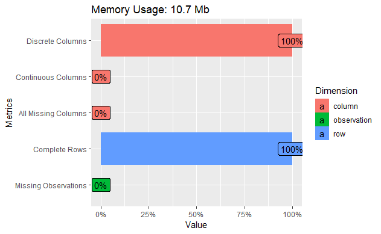

```r
plot_intro(x1)  # View Data 1 data type & completeness
```

ユーザーグループ設定のデータベースの確認。

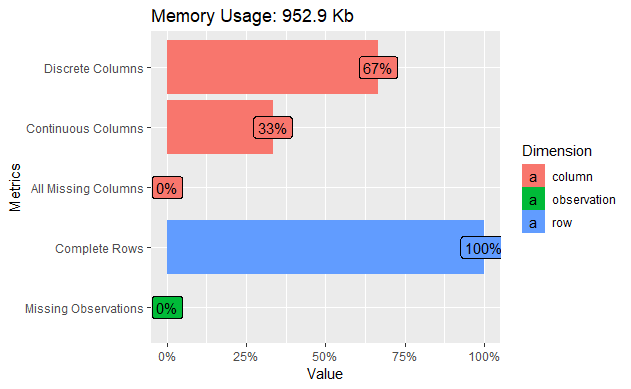

```r
plot_intro(x2)  # View Data 2 data type & completeness
```

二つのデータベースをジョインします。

```r
x1[x2, on = .(user_id = user_id), `:=` (push_cnt = i.push_cnt, msg_type = i.msg_type)] # Join Data 1 with Data 2 using user_id as primay key, copying the push_cnt and msg_type to each user
x1[] # View dataset
```

| user_id | timestamp | push_cnt | msg_type |
| --- | --- | --- | --- |
| u00003805 | 2019-06-02 21:00:00 | 2 | A |
| u00007561 | 2019-06-02 21:00:01 | 1 | B |
| u00004822 | 2019-06-02 21:00:04 | 2 | B |
| u00005147 | 2019-06-02 21:00:05 | 1 | B |
| u00006390 | 2019-06-02 21:00:08 | 1 | A |
| u00000129 | 2019-06-02 21:00:11 | 0 | None |
| u00004804 | 2019-06-02 21:00:12 | 1 | A |
| u00002044 | 2019-06-02 21:00:13 | 2 | A |
| u00006080 | 2019-06-02 21:00:15 | 0 | None |
| u00008362 | 2019-06-02 21:00:15 | 2 | B |

[output cut: 990 more lines]

データベースジョインの確認をします。

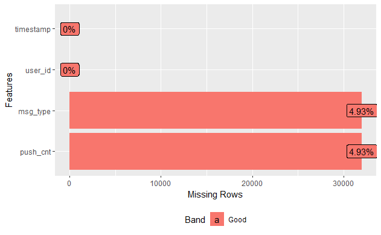

```r
plot_missing(x1) # Verify join effectiveness and dataset completeness
```

以上をみればいくつかのミッシングポイントがあります。 そのポイントが何かと確認します。

```r
x_missing_value = x1[is.na(x1$msg_type),] # Copy rows with error to another dataset
x_missing_value[] # View dataset
```

| user_id | timestamp | push_cnt | msg_type |
| --- | --- | --- | --- |
| u00014786 | 2019-06-02 21:00:40 | NA | NA |
| u00014310 | 2019-06-02 21:02:05 | NA | NA |
| u00020202 | 2019-06-02 21:04:09 | NA | NA |
| u00014112 | 2019-06-02 21:07:48 | NA | NA |
| u00014789 | 2019-06-02 21:08:09 | NA | NA |
| u00021999 | 2019-06-02 21:09:12 | NA | NA |
| u00023046 | 2019-06-02 21:13:00 | NA | NA |
| u00017612 | 2019-06-02 21:13:49 | NA | NA |
| u00013378 | 2019-06-02 21:13:55 | NA | NA |
| u00013576 | 2019-06-02 21:14:48 | NA | NA |

[output cut: 990 more lines]

ログインをしたこのユーザー達は、プッシュメッセージを配信をされないと共に配信される予定もなっかたのです。 こういう時に対する選択は二つあります。一つめはデータを除くこと。二つめはデータを処理すること。

一目散に考えれば予定されていないけれどデータベースに入ったユーザーは、プッシュメッセージを配信されていないユーザーと同じと考えてもよろしいでしょう。 けれどもプッシュをするユーザーの確定基準が知れていないし、このデータベースは65万程のポイントがあるので、除くことを選択しました。

```r
x1 = x1[complete.cases(x1),] # Keep only complete rows in Data 1
x1[] # View Data 1
```

| user_id | timestamp | push_cnt | msg_type |
| --- | --- | --- | --- |
| u00003805 | 2019-06-02 21:00:00 | 2 | A |
| u00007561 | 2019-06-02 21:00:01 | 1 | B |
| u00004822 | 2019-06-02 21:00:04 | 2 | B |
| u00005147 | 2019-06-02 21:00:05 | 1 | B |
| u00006390 | 2019-06-02 21:00:08 | 1 | A |
| u00000129 | 2019-06-02 21:00:11 | 0 | None |
| u00004804 | 2019-06-02 21:00:12 | 1 | A |
| u00002044 | 2019-06-02 21:00:13 | 2 | A |
| u00006080 | 2019-06-02 21:00:15 | 0 | None |
| u00008362 | 2019-06-02 21:00:15 | 2 | B |

[output cut: 990 more lines]

データベースの確認。

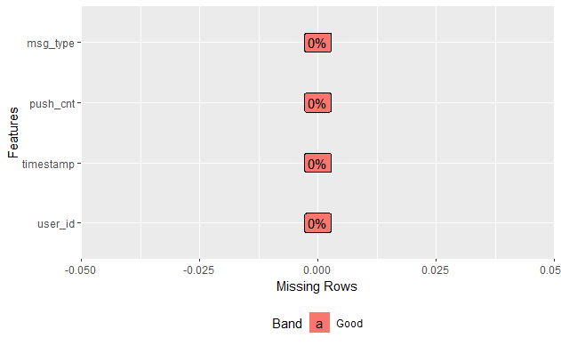

```r
plot_missing(x1) # Verify Data 1 completeness
```

以上でデータクレンジングは終了です。

## 2) 探索的データ解析（EDA）

それではデータ解析を始まります。はじめにデータベースを把握をします。

```r
head(x1[order(user_id),]) # Preview Data 1 ordered alphabetically from user name
```

| user_id | timestamp | push_cnt | msg_type |
| --- | --- | --- | --- |
| u00000001 | 2019-06-02 23:17:11 | 2 | B |
| u00000001 | 2019-06-03 01:35:14 | 2 | B |
| u00000001 | 2019-06-03 03:54:25 | 2 | B |
| u00000001 | 2019-06-03 07:25:12 | 2 | B |
| u00000001 | 2019-06-03 12:19:05 | 2 | B |
| u00000001 | 2019-06-03 13:07:36 | 2 | B |

```
2 columns ignored with more than 50 categories.
user_id: 11595 categories
timestamp: 483750 categories
```

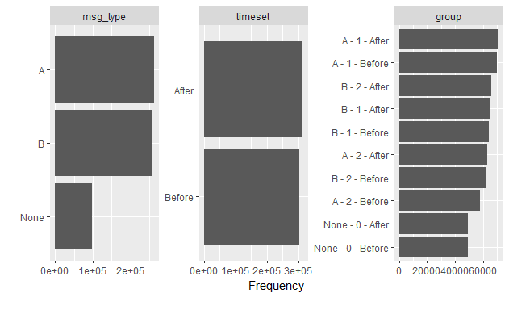

```r
x1[, timeset:=factor(ifelse(timestamp >= "2019-06-10", "After", "Before"), levels = c("Before", "After"))] # Create new column considering the time distance to push notification day, creating hierarchy with labels
x1[, group := factor(paste(msg_type, push_cnt, timeset,   sep = " - "), levels = c("None - 0 - Before",
   "None - 0 - After", "A - 1 - Before", "A - 1 - After", "A - 2 - Before", "A - 2 - After",
   "B - 1 - Before", "B - 1 - After", "B - 2 - Before", "B - 2 - After"))] # Combine 3 coluns to new column using ' - ' as delimiterc, creating hierarchy with labels
plot_bar(x1) # Verify the category variables distributions
```

データベースの確認。

```r
summary(x1) # Verify Data 1 variable types and descriptive statistics
```

```
   user_id            timestamp                      push_cnt
 Length:617465      Min.   :2019-06-02 21:00:00   Min.   :0.000
 Class :character   1st Qu.:2019-06-06 12:01:42   1st Qu.:1.000
 Mode  :character   Median :2019-06-10 02:42:43   Median :1.000
                    Mean   :2019-06-09 23:58:34   Mean   :1.243
                    3rd Qu.:2019-06-13 11:49:32   3rd Qu.:2.000
                    Max.   :2019-06-16 20:59:59   Max.   :2.000

   msg_type           timeset                  group
 Length:617465      Before:303540   A - 1 - After : 70681
 Class :character   After :313925   A - 1 - Before: 70267
 Mode  :character                   B - 2 - After : 65815
                                    B - 1 - After : 64892
                                    B - 1 - Before: 64450
                                    A - 2 - After : 63086
                                    (Other)       :218274
```

以上をみれば予定以外の日にちがあります（06/03~06/16)。 それらを除いて、グループアップをしやすくするため、日付を新しいコルムへ入れます。

```r
x1[, date:=date(timestamp)]
x1 = x1[date > "2019-06-02" & date <= "2019-06-16"]  # Remove dates before 06/02 (exclusive )and 16/06 (inclusive)
summary(x1)  # Verify Data 1 variable types and descriptive statistics
```

```
   user_id            timestamp                      push_cnt
 Length:612302      Min.   :2019-06-03 00:00:01   Min.   :0.000
 Class :character   1st Qu.:2019-06-06 14:13:32   1st Qu.:1.000
 Mode  :character   Median :2019-06-10 04:04:12   Median :1.000
                    Mean   :2019-06-10 01:24:18   Mean   :1.243
                    3rd Qu.:2019-06-13 12:33:26   3rd Qu.:2.000
                    Max.   :2019-06-16 20:59:59   Max.   :2.000

   msg_type           timeset                  group
 Length:612302      Before:298377   A - 1 - After : 70681
 Class :character   After :313925   A - 1 - Before: 69082
 Mode  :character                   B - 2 - After : 65815
                                    B - 1 - After : 64892
                                    B - 1 - Before: 63343
                                    A - 2 - After : 63086
                                    (Other)       :215403
      date
 Min.   :2019-06-03
 1st Qu.:2019-06-06
 Median :2019-06-10
 Mean   :2019-06-09
 3rd Qu.:2019-06-13
 Max.   :2019-06-16
```

ですが、この状態では、ログイン回数の比較ができません。なので1日中のトータルログイン回へと変更します。 その後、ログイン回に日にちの影響を軽減する為に、平均を計算します。

```r
x1 = x1[, .N, by=.(user_id, date, timeset, push_cnt, msg_type, group)] # Group up the Data 1, save the group counting to a new variable N., grouping by User Name and the Rows Day. Keep these columns
x1 = x1[, .(login_mean = mean(N)), by=.(user_id, timeset, push_cnt, msg_type, group)] # Get the mean of the Group Size and save to new variable 'login_mean'. Keep these columns
x1[order(user_id)] # Preview Data 1 ordered alphabetically from user name
```

| user_id | timeset | push_cnt | msg_type | group | login_mean |
| --- | --- | --- | --- | --- | --- |
| u00000001 | Before | 2 | B | B - 2 - Before | 4.142857 |
| u00000001 | After | 2 | B | B - 2 - After | 4.714286 |
| u00000002 | Before | 2 | B | B - 2 - Before | 4.285714 |
| u00000002 | After | 2 | B | B - 2 - After | 5.166667 |
| u00000003 | Before | 2 | A | A - 2 - Before | 3.428571 |
| u00000003 | After | 2 | A | A - 2 - After | 3.857143 |
| u00000004 | Before | 0 | None | None - 0 - Before | 3.714286 |
| u00000004 | After | 0 | None | None - 0 - After | 3.571429 |
| u00000005 | Before | 2 | B | B - 2 - Before | 3.285714 |
| u00000005 | After | 2 | B | B - 2 - After | 4.500000 |

[output cut: 990 more lines]

beforeログイン回とafterログイン回をデンシティ図表で比べます。

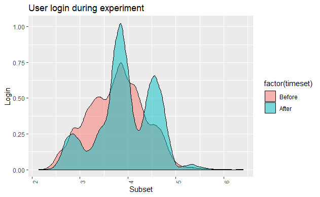

```r
ggplot(x1) + # Plot x1
  geom_density(aes(x = login_mean, fill = factor(timeset)), alpha = 0.5) + # As density chart,
  labs(x = "Subset", y = "Login", title = "User login during experiment") + # Chart labels
  theme(axis.text.x = element_text(angle = 90)) # Rotate X axis
```

この様にbeforeセットは一つの分布にみえます。けれどもafterセットはおおきい凸凹は三っつ程見えます。これは何故かと言いますと、いろんな分布が混ざっているからです。

同じく、前のログイン回と後のログイン回を、次はボックスプロット図で比べます。

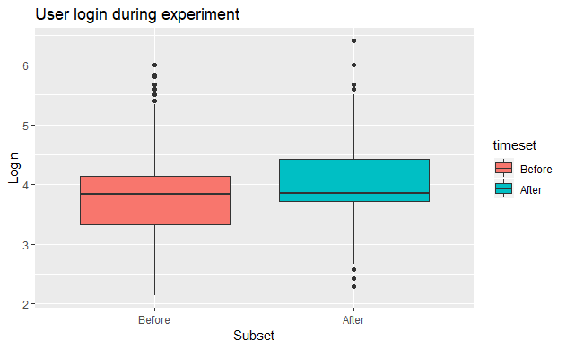

```r
ggplot(x1) + # Plot x1
  geom_boxplot(aes(x = timeset, y = login_mean, fill = timeset)) + # Plot a boxplot chart of the mean login time per user, using group before and after, with the colors separating
  labs(x = "Subset", y = "Login", title = "User login during experiment")  # Chart Labels
```

以上で見える様に、プッシュメッセージ後のログイン回は上がりました。けれどもafterの図にはプッシュメッセージを配信されていないユーザー群がいます。それに外れ値（outlier）が多すぎです。こういう時には、outlierを処理するのが最適ですが、ユーザー達の他の情報が無いので、処理はしないと判断しました。 分析を進めてデータベースを他のグループに分かれます。

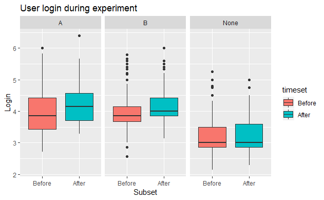

```r
ggplot(x1) + # Plot x1
  geom_boxplot(aes(x = timeset, y = login_mean, fill = timeset)) +# Plot a boxplot chart of the mean login time per user, using group before and after, with the colors separating
  facet_wrap(vars(msg_type)) + # Create serveral blocks conditioned by the message type category
  labs(x = "Subset", y = "Login", title = "User login during experiment")  # Chart labels
```

以上で見えるように、ログイン回が上がったのはAとBグループ。プッシュメッセージを配信されていないグループは、ほとんど変わっていません。 それに加えて、今度はプッシュ回にて分かれ、分析を進めます。

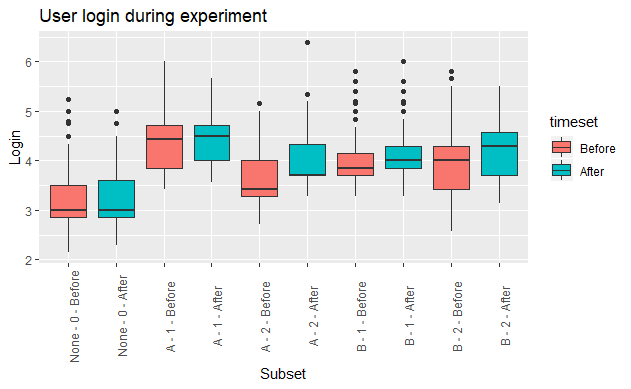

```r
ggplot(x1) + # Plot x1
  geom_boxplot(aes(x = group, y = login_mean, fill = timeset)) +  # Plot a boxplot chart of the mean login time per user, using group before and after, with the colors separating
  labs(x = "Subset", y = "Login", title = "User login during experiment") + # Chart Labels
  theme(axis.text.x = element_text(angle = 90)) # Rotate x labels
```

## 3) 仮設検定（hypothesis test）

ユーザーのログイン回が上がったかどうかの仮設検定をするためには、大きく分かれて正規分布であるかどうかを規定する必要があります。 それでは正規分布テストのためにQ-Qプロットを使います。

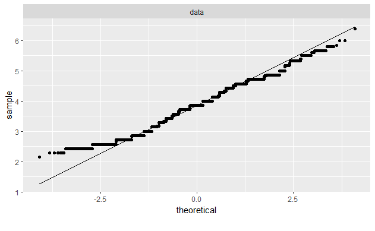

```r
plot_qq(x1$login_mean) # Quantile x Quantile Plot for the average daily login before and after push notification
```

以上のようにログイン回の分布は、ヴィジュアル的に、正規分布ではありません。 それを確かめるために Kolmogorov-Smirnov テストを使います。

```r
ks.test(x1$login_mean[], y='pnorm') # Non parametrical normality hypothesis test for the average daily login before and after push notification
```

```
ties should not be present for the Kolmogorov-Smirnov test
```

```
    One-sample Kolmogorov-Smirnov test

data:  x1$login_mean[]
D = 0.99212, p-value < 2.2e-16
alternative hypothesis: two-sided
```

以上のように、 p-value < 2.2e-16 が５％以下なので、この正規分布の仮設は反論します。 けれどもボックスプロット図で見えた様に、outlierが多いです。この様な状態では、線型写像（linear transformation）を使って、データベースを正規分布に変換出来る可能性があります。

```r
x3 = x1[, x_norm := scale(login_mean, center = TRUE, scale = FALSE), by = group] # Normalize the average daily login before and after push notification
ks.test(x3$x_norm[x3$group == "A - 1 - Before"], y='pnorm') # Non parametrical normality hypothesis test for the average daily login before and after push notification
```

```
ties should not be present for the Kolmogorov-Smirnov test
```

```
    One-sample Kolmogorov-Smirnov test

data:  x3$x_norm[x3$group == "A - 1 - Before"]
D = 0.25962, p-value < 2.2e-16
alternative hypothesis: two-sided
```

変換をしても、正規分布には近づけませんでした。

データベースが正規分布ではないから、平均比べのパラメトリック仮設検定（t検定、その他）は使えません。だから中央値比べのノンパラメトリック仮設検定（この度はウィルコクソンの順位和検定）をつかいます。

```r
wilcox.test(login_mean ~ timeset, data = x1, alternative = "less") # Non parametrical median  hypothesis test, for 2 groups, for the average daily login before and after push notification
```

```
    Wilcoxon rank sum test with continuity correction

data:  login_mean by timeset
W = 55163000, p-value < 2.2e-16
alternative hypothesis: true location shift is less than 0
```

以上のように p-value < 2.2e-16 が５％以下なのでボックスプロットで見えた様にbeforeとafterのグループのログイン回に違いがあって、afterはbeforeよりもログイン回が上がりました。どのグループが誰と違うかを定めます。

```r
pairwise.wilcox.test(x1$login_mean, x1$group) # Non parametrical median  hypothesis test, for 2 groups, versus all groups, for the average daily login before and after push notification
```

```
    Pairwise comparisons using Wilcoxon rank sum test

data:  x1$login_mean and x1$group

                 None - 0 - Before None - 0 - After A - 1 - Before
None - 0 - After 2.5e-06           -                -
A - 1 - Before   < 2e-16           < 2e-16          -
A - 1 - After    < 2e-16           < 2e-16          < 2e-16
A - 2 - Before   < 2e-16           < 2e-16          < 2e-16
A - 2 - After    < 2e-16           < 2e-16          < 2e-16
B - 1 - Before   < 2e-16           < 2e-16          < 2e-16
B - 1 - After    < 2e-16           < 2e-16          < 2e-16
B - 2 - Before   < 2e-16           < 2e-16          < 2e-16
B - 2 - After    < 2e-16           < 2e-16          < 2e-16
                 A - 1 - After A - 2 - Before A - 2 - After B - 1 - Before
None - 0 - After -             -              -             -
A - 1 - Before   -             -              -             -
A - 1 - After    -             -              -             -
A - 2 - Before   < 2e-16       -              -             -
A - 2 - After    < 2e-16       < 2e-16        -             -
B - 1 - Before   < 2e-16       < 2e-16        < 2e-16       -
B - 1 - After    < 2e-16       < 2e-16        < 2e-16       < 2e-16
B - 2 - Before   < 2e-16       < 2e-16        < 2e-16       1.6e-12
B - 2 - After    < 2e-16       < 2e-16        < 2e-16       < 2e-16
                 B - 1 - After B - 2 - Before
None - 0 - After -             -
A - 1 - Before   -             -
A - 1 - After    -             -
A - 2 - Before   -             -
A - 2 - After    -             -
B - 1 - Before   -             -
B - 1 - After    -             -
B - 2 - Before   < 2e-16       -
B - 2 - After    4.7e-07       < 2e-16

P value adjustment method: holm
```

## 4) 結論

それではグループ達の統計を計算します。

```r
group_by(x1, group) %>% # With the x1, by group
  summarise( # Resume for me with
    count = n(), # Size of the group
    mean = mean(login_mean, na.rm = TRUE), # Average daily login
    sd = sd(login_mean, na.rm = TRUE), # Standard deviation
    median = median(login_mean, na.rm = TRUE), # Median
    IQR = IQR(login_mean, na.rm = TRUE) # Inter quartile Size
  )
```

| group | count | mean | sd | median | IQR |
| --- | --- | --- | --- | --- | --- |
| None - 0 - Before | 2319 | 3.121448 | 0.4400335 | 3.000000 | 0.6428571 |
| None - 0 - After | 2319 | 3.187518 | 0.4712493 | 3.000000 | 0.7428571 |
| A - 1 - Before | 2319 | 4.306454 | 0.4393678 | 4.428571 | 0.8571429 |
| A - 1 - After | 2319 | 4.400023 | 0.4019430 | 4.500000 | 0.7142857 |
| A - 2 - Before | 2319 | 3.598359 | 0.4314995 | 3.428571 | 0.7142857 |
| A - 2 - After | 2319 | 3.957028 | 0.4016796 | 3.714286 | 0.6190476 |
| B - 1 - Before | 2319 | 3.971203 | 0.2981223 | 3.857143 | 0.4285714 |
| B - 1 - After | 2319 | 4.066539 | 0.3069454 | 4.000000 | 0.4285714 |
| B - 2 - Before | 2319 | 3.838516 | 0.5186583 | 4.000000 | 0.8571429 |
| B - 2 - After | 2319 | 4.128836 | 0.5410302 | 4.285714 | 0.8571429 |

## 5) 最後に（next step)

- **サンプリング**: どのユーザーがどのメッセージを配信されるかの決定理由の把握。
- **外れ値**: outlierの理由を理解して処理すること。
- **他の特徴**: ユーザーのログイン回を、前置きに、他の特徴にてグループアップして、その後に施策立案を行うこと
- このポイントは重要です。前置きに同じな行動をとるユーザー達を比べなければ、後の結論がビアスのせいで色々な疑問点が浮かびます。
- このリスクを納めるためにデータ・クラスタリングを行うことを勧めます。